# Hypothesis Testing

## Objective:

### The project aims to assess if a new ad campaign (Test group) drives more purchases than the current one (Control group) using statistical analysis, including t-test & assessing p-value. This will guide whether to adopt the new campaign strategy.

### Null Hypothesis (H₀): There is no difference in conversion rates between control and test groups.

### Alternative Hypothesis (H₁): There is a difference in conversion rates between control and test groups.

##### Dataset link: https://www.kaggle.com/datasets/amirmotefaker/ab-testing-dataset

### First of all, I import the necessary libraries. Here, these two are more than enough!

```python
import pandas as pd
from scipy import stats
```

### Loading given two csv files. Here control group is the old or current campaign strategy while test group is the new campaign strategy, consider it an unseen group.

```python
control = pd.read_csv("control_group.csv", sep=";")
test = pd.read_csv("test_group.csv", sep=";")
```

```python
control["group"] = "control"
test["group"] = "test"
```

### Merging two csv's into one for the best analysis

```python
data = pd.concat([control, test], ignore_index=True)
```

### Output of the merged dataset

```python
print(data.head())
```

```
      Campaign Name       Date  Spend [USD]  # of Impressions     Reach  \
0  Control Campaign  1.08.2019         2280           82702.0   56930.0
1  Control Campaign  2.08.2019         1757          121040.0  102513.0
2  Control Campaign  3.08.2019         2343          131711.0  110862.0
3  Control Campaign  4.08.2019         1940           72878.0   61235.0
4  Control Campaign  5.08.2019         1835               NaN       NaN

   # of Website Clicks  # of Searches  # of View Content  # of Add to Cart  \
0               7016.0         2290.0             2159.0            1819.0
1               8110.0         2033.0             1841.0            1219.0
2               6508.0         1737.0             1549.0            1134.0
3               3065.0         1042.0              982.0            1183.0
4                  NaN            NaN                NaN               NaN

   # of Purchase    group
0          618.0  control
1          511.0  control
2          372.0  control
3          340.0  control
4            NaN  control
```

### Checking for Null Values in '# of Purchase' Column

```python
null_count = data["# of Purchase"].isnull().sum()
print("Number of null values in '# of Purchase':", null_count)
```

```
Number of null values in '# of Purchase': 1
```

### Calculating the Mean Summary for 'Spend [USD]', 'Website Clicks', and 'Purchase' by Group

```python
summary = df_clean.groupby("group")[["Spend [USD]", "# of Website Clicks", "# of Purchase"]].mean()
print(summary)
```

```
         Spend [USD]  # of Website Clicks  # of Purchase
group
control  2304.068966          5320.793103     522.793103
test     2563.066667          6032.333333     521.233333
```

### Calculating the Conversion Rate as Ratio of 'Purchase' to 'Website Clicks'

```python
df_clean["conversion_rate"] = df_clean["# of Purchase"] / df_clean["# of Website Clicks"]
```

```python
conversion_summary = df_clean.groupby("group")["conversion_rate"].mean()
print(conversion_summary)
```

```
group
control    0.114772
test       0.092312
Name: conversion_rate, dtype: float64
```

### Performing t-test on Conversion Rates & Printing t-statistic and p-value

```python
from scipy.stats import ttest_ind

control_rates = df_clean[df_clean["group"] == "control"]["conversion_rate"]
test_rates = df_clean[df_clean["group"] == "test"]["conversion_rate"]

t_stat, p_value = ttest_ind(test_rates, control_rates, equal_var=False)
print("T-statistic:", t_stat)
print("P-value:", p_value)
```

```
T-statistic: -1.4899942228754453
P-value: 0.14278642437865938
```

### Here, p > 0.05 → So, I can't reject Null Hypothesis.

### There is no significant difference in performance between the control and test group.

# Result: The new ad campaign doesn't bring more purchase significantly compared to old one.

### One more thing before wrapping all up! Let's see how the conversion rate of these two groups look like!

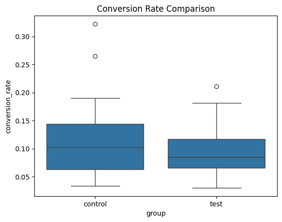

```python
import seaborn as sns
import matplotlib.pyplot as plt

sns.boxplot(x="group", y="conversion_rate", data=df_clean)
plt.title("Conversion Rate Comparison")
plt.show()
```

### See! The rate is almost similar. That's what I found in the statistical test as well.